# GCCR Factor Influence

# JBonds. Average Scores. Momentum

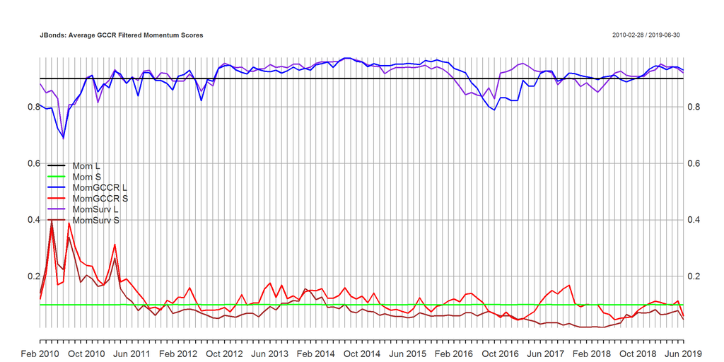

# JBonds. Average Scores. Momentum. Summary

- Survived (0 and 1): TOP: no effect, BOT: the compnaies tend to have < 0.1 score. Survived companies used to have lower momentum!
- Good (Only 1): The picture shows that the behavior of the top and the bottom firms in terms of momentum remains more or less the same last 10 years.

# JBonds. Average Scores. Size

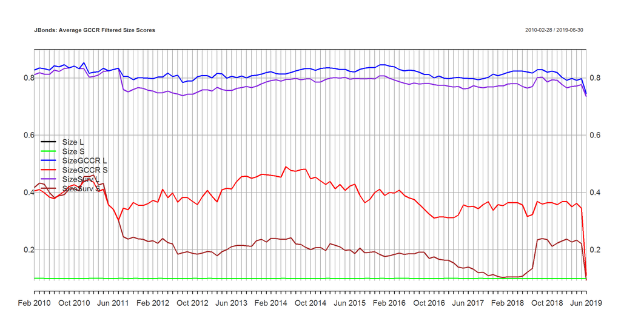

# JBonds. Average Scores. Size. Summary

- There is a feature: there is no convergence to 0.9. This is ok, since the normalization of the size factor is done for the whole universe (JBonds and IGBonds). Taking into account only JBOnds the average score is not supposed to be 0.9 anymore. Moreover, it is supposed to be lower than 0.9, since JBonds are issued by smaller companies.
- Survived (0 and 1): The top portfolio does not corverge to 0.9. This means that the look-ahead bias eliminates the biggest companies. This pattern is robust, meaning that the top companies were consistently relatively smaller than 0.9. BOT: look-ahead bias leaves out smaller companies and the convergence is too steeply (within 1 month). This fact can be explained by increaded universe in 2019. Accepting this hypothesis, size score was relatively stable.
- Good (Only 1): TOP&BOT: SustFilter leaves out smaller companies. BOT: The difference in sizes “before” and “now” is too big.

# IGBonds. Average Scores. Momentum

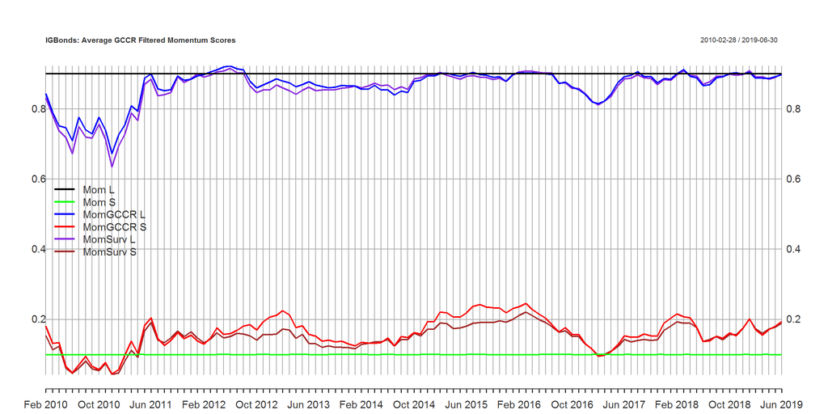

# IGBonds. Average Scores. Momentum. Summary

- Survived (0 and 1): TOP: the look-ahead bias tends to eliminate the high-momentum companies. BOT: the look-ahead bias tends to eliminate the low-momentum companies (effect is bigger). This pattern is robust. There is no convergence.
- Good (Only 1): TOP: no effect, BOT: survivorship bias effect is increased a bit.

# IGBonds. Average Scores. Size

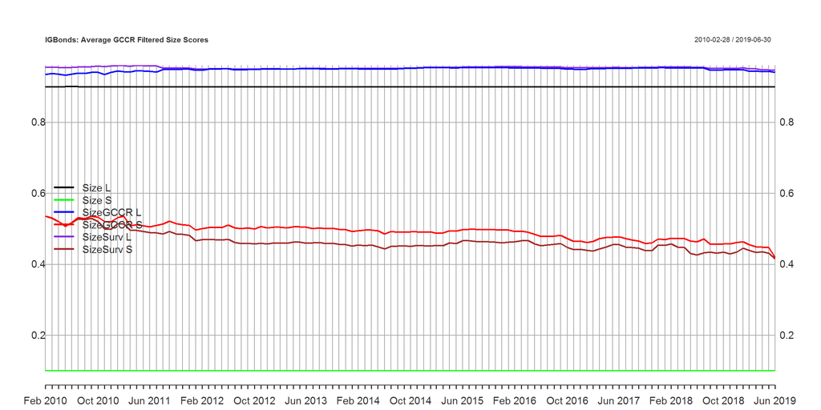

# IGBonds. Average Scores. Size

- Survived (0 and 1): Here the difference is huge! The look-ahead bias consistently drops smaller companies. Except this, the relative score remains more or less constant, meaning that the companies in both portfolios (top and bottom) were relatively (compared with the peers) the same in terms of size.
- Good (Only 1): TOP: no effect, BOT: survivorship bias effect is increased.
- There is a feature: the BOT score is so high since the normalization of the size factor is done for the whole universe. Taking into account only IG BOnds the average score is not supposed to be 0.1 anymore. Moreover, it is supposed to be higher than 0.1 since IG Bonds are issued by big companies.

# Conclusions: Part 2

- For equities there is a weak pattern in momentum: companies that are in index now used to have a bit higher momentum, compared with peers.
- The is strong pattern in size: survived companies used to have higher size score, meaning that these companies were big (only the biggest survived).
- There is a weak pattern in value: companies that are in index now used to have a bit lower value, compared with peers.
- In the U.S. market and Europe (except of the TOP size) filtering does not have any influence.
- In the Emerging Markets and both bonds filtering has an effect.